# How to Sell Out for Popularity in Music

Data Driven Recommendations for Making Songs to Limit Spotify Skips

kmhurchla@gmail.com

April 29, 2021

[figure not shown]

[figure not shown]

Navigate easily by clicking the blue button in the upper left corner for shortcuts around this EDA notebook.

# Exploratory Data Analysis notebook

| track_id_clean | n |
| --- | --- |
| t_bacf06d3-9185-4183-84ea-ff0db51475ce | 1427 |
| t_5718ab08-3a15-4d3f-9e63-42b2f6805e31 | 915 |
| t_8c4d29b1-e0bf-464c-88f7-ac19240cbba0 | 785 |
| t_a66ea088-b357-449a-8a1e-64dd0b8d6cb5 | 730 |
| t_77b02acb-1b1f-4b36-b8fc-2c3e01892b9a | 719 |
| t_9a31436c-a57a-4d7a-9bbc-50f0deca33de | 612 |
| t_0e3dec82-10b4-49f1-8c2e-cd19249f7d2c | 600 |
| t_2fd6279a-06cd-4d5d-9e54-1912f51bb3c3 | 593 |
| t_7533e7ff-568e-448b-904e-fc0c3a9ec87e | 576 |
| t_29a3895e-2c91-49a6-9383-6a71c597390d | 548 |

[output cut: 990 more lines]

```
Rows: 312
Columns: 36
$ track_id_clean         <chr> "t_00750953-913d-4950-94a2-285b662c32f3", "t_01d0b9bd-9b4c-4245-8e9e-1dd6b09be4b8", "t_01d7104d-d28c-4c56-9012-d22ef2b8bdc9", "t_0214ad9b-a913-43f4-9111-0c04f54…
$ plays                  <int> 148, 94, 53, 58, 56, 112, 82, 79, 79, 56, 600, 50, 536, 167, 53, 122, 73, 50, 88, 88, 72, 72, 52, 59, 82, 51, 73, 51, 57, 78, 91, 67, 128, 437, 120, 69, 68, 214…
$ skip_1                 <int> 55, 33, 15, 30, 20, 43, 37, 31, 43, 25, 239, 27, 287, 70, 23, 39, 31, 27, 23, 44, 27, 28, 28, 14, 47, 16, 15, 28, 16, 34, 38, 24, 53, 197, 49, 28, 31, 110, 25, …
$ skip_2                 <int> 77, 44, 25, 40, 28, 47, 48, 35, 49, 29, 281, 30, 321, 82, 27, 54, 38, 40, 32, 45, 38, 35, 35, 21, 50, 21, 27, 31, 20, 36, 42, 29, 65, 227, 62, 34, 43, 136, 36, …
$ skip_3                 <int> 97, 63, 28, 46, 30, 64, 59, 47, 58, 34, 343, 37, 376, 111, 30, 76, 45, 42, 47, 52, 54, 42, 39, 31, 54, 26, 35, 36, 29, 42, 51, 37, 86, 274, 93, 46, 51, 173, 45,…
$ not_skipped            <int> 49, 1, 24, 11, 26, 47, 22, 30, 19, 22, 248, 13, 154, 54, 22, 45, 27, 8, 37, 34, 18, 26, 13, 26, 27, 22, 36, 14, 26, 33, 38, 29, 42, 160, 27, 22, 17, 40, 4, 22, …
$ not_skipped_pct        <dbl> 0.33108108, 0.01063830, 0.45283019, 0.18965517, 0.46428571, 0.41964286, 0.26829268, 0.37974684, 0.24050633, 0.39285714, 0.41333333, 0.26000000, 0.28731343, 0.32…
$ duration               <dbl> 175.77464, 183.90668, 195.51900, 204.60001, 99.65832, 204.42667, 212.50076, 207.25551, 163.20000, 221.74698, 205.14667, 250.17332, 198.97333, 332.30090, 249.608…
$ release_year           <dbl> 2018, 2017, 2018, 2017, 2018, 2018, 2018, 2018, 2018, 2017, 2018, 2017, 2018, 2018, 2018, 2018, 2018, 2018, 2018, 2017, 2018, 2018, 2018, 2016, 2017, 2017, 2018…
$ us_popularity_estimate <dbl> 99.99898, 99.99822, 99.99979, 99.99948, 99.99907, 99.99976, 99.99318, 99.98324, 99.99897, 99.99970, 99.99986, 99.99976, 99.99994, 99.99980, 99.99869, 99.99990, …
$ acousticness           <dbl> 0.0121257138, 0.1936447173, 0.0028115376, 0.0101807714, 0.9755389690, 0.4139715135, 0.0298306700, 0.1661845148, 0.0966448113, 0.6171661019, 0.0456176884, 0.5697…
$ beat_strength          <dbl> 0.8859758, 0.6366841, 0.4961974, 0.6939233, 0.3693140, 0.3133208, 0.4573658, 0.6966938, 0.7968707, 0.6679351, 0.8109947, 0.4353088, 0.7803839, 0.5549759, 0.7202…
$ bounciness             <dbl> 0.9271444, 0.6364808, 0.4455178, 0.7632633, 0.3744994, 0.3189231, 0.5260238, 0.7347806, 0.8010411, 0.6372618, 0.8336291, 0.4224693, 0.7435990, 0.6473960, 0.7688…
```

[output cut: 23 more lines]

### Initial Scatterplots by Features

Let’s take some peeks for relationships of playing songs through with some of our audio features.

[figure not shown]

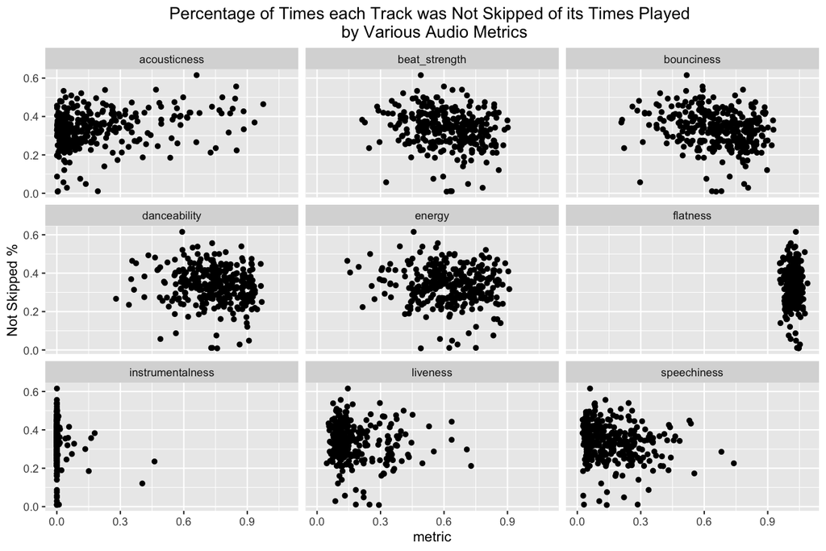

*Conclusion*: No strong/obvious visually apparant patterns of correlation can be seen in these scatterplots to address our inquiry of music’s features with likelihood of being skipped.

**SHAPE OF TRACKS**

Next, we’re going to look at most and least skipped tracks on a radial chart (aka a spider, web, polor or radar charts/graphs). Before we do so, it’s important to note this graph type may make comparisons more difficult than linear styles in some situations, and you can read more about that here: https://www.data-to-viz.com/caveat/spider.html

Our situation is already normalized where the axis of each audio metric is the same which lends itself to more easily understandable and visually accurate view, for example it will be read more logically and accurately than if your flatness scale was 0 to 1 but energy was 0 to 10, etc.

| track_id_clean | plays | skip_1 | skip_2 | skip_3 | not_skipped | not_skipped_pct | duration | release_year | us_popularity_estimate | acousticness | beat_strength | bounciness | danceability | dyn_range_mean | energy | flatness | instrumentalness | key | liveness | loudness | mechanism | mode | organism | speechiness | tempo | time_signature | valence | acoustic_vector_0 | acoustic_vector_1 | … |
| --- | --- | --- | --- | --- | --- | --- | --- | --- | --- | --- | --- | --- | --- | --- | --- | --- | --- | --- | --- | --- | --- | --- | --- | --- | --- | --- | --- | --- | --- | --- |
| t_fc5df5ba-5396-49a7-8b29-35d0d28249e0 | 277 | 91 | 111 | 141 | 131 | 0.4729242 | 231.2667 | 2018 | 99.99998 | 0.35411644 | 0.5321552 | 0.5404109 | 0.6797193 | 8.065802 | 0.5630089 | 1.0294654 | 0.0000000265903513 | 10 | 0.13577576 | -5.843 | 0.7743271 | major | 0.2969231 | 0.04535428 | 145.028 | 4 | 0.3738621 | -0.7425408 | 0.3755992 | … |
| t_fce005ac-ac50-468a-ae8c-be42b4b6edcd | 51 | 17 | 29 | 35 | 16 | 0.3137255 | 203.4000 | 2018 | 99.99828 | 0.19181940 | 0.4254028 | 0.4194166 | 0.3646680 | 6.825529 | 0.6918172 | 1.0268339 | 0.0000015122926698 | 3 | 0.08617508 | -4.586 | 0.3938356 | minor | 0.4495720 | 0.06712231 | 89.998 | 4 | 0.3716313 | -0.6053437 | 0.3531733 | … |
| t_fec4d8aa-7ff4-418b-b3d8-835ca0f7672e | 192 | 87 | 101 | 134 | 57 | 0.2968750 | 161.0133 | 2018 | 99.99980 | 0.02539228 | 0.8089568 | 0.8750140 | 0.9363900 | 14.996685 | 0.4954246 | 1.0538664 | 0.0000000000883577 | 1 | 0.08703568 | -6.062 | 0.8287671 | major | 0.1224040 | 0.22916549 | 139.951 | 4 | 0.2985733 | -0.8030788 | 0.2980381 | … |
| t_ff2c96eb-7063-4094-8d91-c45a5f3eb230 | 91 | 40 | 52 | 64 | 27 | 0.2967033 | 189.4013 | 2018 | 97.82787 | 0.08292492 | 0.4013238 | 0.4267530 | 0.6073564 | 7.156329 | 0.7395036 | 0.9975393 | 0.0000000106861657 | 4 | 0.10513421 | -4.793 | 0.3633333 | minor | 0.4539939 | 0.17155994 | 108.050 | 4 | 0.2194498 | -0.3221056 | 0.4773510 | … |
| t_ff63727c-b0b9-4988-98a5-10858db83ac9 | 56 | 23 | 29 | 38 | 15 | 0.2678571 | 264.5316 | 2017 | 99.99961 | 0.06516206 | 0.5873259 | 0.6591122 | 0.7359634 | 10.024789 | 0.6036724 | 1.0310866 | 0.0000643250241410 | 1 | 0.12350819 | -7.357 | 0.7379768 | minor | 0.1909218 | 0.22185422 | 155.007 | 4 | 0.5743871 | -0.8643624 | 0.3116999 | … |
| t_ffc37789-d3ce-4aa6-8e89-067ab0f18b21 | 62 | 34 | 47 | 48 | 3 | 0.0483871 | 197.3067 | 2018 | 99.99771 | 0.13678221 | 0.7135774 | 0.7886605 | 0.9079530 | 12.281156 | 0.6381349 | 1.0338607 | 0.0000140744368764 | 10 | 0.22036265 | -6.663 | 0.7725947 | minor | 0.1876466 | 0.22082488 | 130.007 | 4 | 0.3880620 | -0.7819443 | 0.2702689 | … |

## Radar Requirements Checklist & Data Preparations

How far we are from what is required for a radar chart?

**1. Each row must be an entity.** + Each row represents a unique track (track_id_clean).

**2. Each column is a quantitative variable.** + Currently, columns contain summarized aggregations of its plays/skips, + and columns for other quantitative attributes like energy, dancability, etc. + We need to remove or drop any columns that won’t show in the graph, or are not quantitative.

**3. First 2 rows provide the min and the max** that will be used for each variable. + To set these range(s), we’ll refer to both Spotify Developer documentation and review min/max of our data. + Goals are to keep a single consistent range as much as possible, and + provide logical and accurate ranges, which I’ve found has required music terminology research in some cases.

```
Rows: 6
Columns: 36
$ track_id_clean         <chr> "t_fc5df5ba-5396-49a7-8b29-35d0d28249e0", "t_fce005ac-ac50-468a-ae8c-be42b4b6edcd", "t_fec4d8aa-7ff4-418b-b3d8-835ca0f7672e", "t_ff2c96eb-7063-4094-8d91-c45a5f3…
$ plays                  <int> 277, 51, 192, 91, 56, 62
$ skip_1                 <int> 91, 17, 87, 40, 23, 34
$ skip_2                 <int> 111, 29, 101, 52, 29, 47
$ skip_3                 <int> 141, 35, 134, 64, 38, 48
$ not_skipped            <int> 131, 16, 57, 27, 15, 3
$ not_skipped_pct        <dbl> 0.4729242, 0.3137255, 0.2968750, 0.2967033, 0.2678571, 0.0483871
$ duration               <dbl> 231.2667, 203.4000, 161.0133, 189.4013, 264.5316, 197.3067
$ release_year           <dbl> 2018, 2018, 2018, 2018, 2017, 2018
$ us_popularity_estimate <dbl> 99.99998, 99.99828, 99.99980, 97.82787, 99.99961, 99.99771
$ acousticness           <dbl> 0.35411644, 0.19181940, 0.02539228, 0.08292492, 0.06516206, 0.13678221
$ beat_strength          <dbl> 0.5321552, 0.4254028, 0.8089568, 0.4013238, 0.5873259, 0.7135774
$ bounciness             <dbl> 0.5404109, 0.4194166, 0.8750140, 0.4267530, 0.6591122, 0.7886605
```

[output cut: 23 more lines]

```
[1] "t_fc5df5ba-5396-49a7-8b29-35d0d28249e0" "t_fce005ac-ac50-468a-ae8c-be42b4b6edcd" "t_fec4d8aa-7ff4-418b-b3d8-835ca0f7672e" "t_ff2c96eb-7063-4094-8d91-c45a5f3eb230"
[5] "t_ff63727c-b0b9-4988-98a5-10858db83ac9" "t_ffc37789-d3ce-4aa6-8e89-067ab0f18b21"
```

**2. Again, each column is a quantitative variable:** *Non-quantitative or columns unnecessary for this chart will be removed:*

- $ not_skipped_pct
- *We’re sorting by this descending, and there’s no real use in visualizing it since our goal is to visualize the attributes of audio that makes it popular, i.e. not skipped frequently.*
- $ track_id_clean
- *It seems according to instructions this is no longer needed; row represent an entity but id is unnecessary for chart (since songs are anonymized it really doesn’t matter here.)*
- $ plays
- *(We’re already representing this by descending order of the percentage, which will also order our separate charts dispayed).*
- $ skip_1 (and 2,3)
- *(for our purposes, we’ll simplify to only analyze skipped or not skipped, as normalized by the percentage aggregation)*
- $ not_skipped
- *(redundant; same reasons as above)*
- $ duration
- *let’s try it first, scale is vastly different than other columns and may be confusing–we’ll need to explicitly label each axis to try)*
- $ release_year
- *ditto duration; I think this will be better as a caption/detail attribute, but we can try first.*
- $ us_popularity_estimate
- *ditto duration; this in other published models has shown to be the most indicative of success (least skips), but the scale is very large so we may have trouble with that.*
- $ mode
- *character type: major, minor. Move to a caption label or ignore.*
- $ acoustic_vector_0 (and 1-7)
- *Remove for separate plotting; we’ll assign a new variable table for this analysis so we can easily return to work with these separately.*
- $ dyn_range_mean
- *removed as redundant and rolled up into energy; also has a very distinct 0 to 35 scale range different from other features.*

Everything else is a double type and we’ll try with labelled axis on each, and determine if it’s too much, too busy, and go from there.

```
Rows: 6
Columns: 19
$ duration               <dbl> 231.2667, 203.4000, 161.0133, 189.4013, 264.5316, 197.3067
$ release_year           <dbl> 2018, 2018, 2018, 2018, 2017, 2018
$ us_popularity_estimate <dbl> 99.99998, 99.99828, 99.99980, 97.82787, 99.99961, 99.99771
$ acousticness           <dbl> 0.35411644, 0.19181940, 0.02539228, 0.08292492, 0.06516206, 0.13678221
$ beat_strength          <dbl> 0.5321552, 0.4254028, 0.8089568, 0.4013238, 0.5873259, 0.7135774
$ bounciness             <dbl> 0.5404109, 0.4194166, 0.8750140, 0.4267530, 0.6591122, 0.7886605
$ danceability           <dbl> 0.6797193, 0.3646680, 0.9363900, 0.6073564, 0.7359634, 0.9079530
$ energy                 <dbl> 0.5630089, 0.6918172, 0.4954246, 0.7395036, 0.6036724, 0.6381349
$ flatness               <dbl> 1.0294654, 1.0268339, 1.0538664, 0.9975393, 1.0310866, 1.0338607
$ instrumentalness       <dbl> 0.0000000265903513, 0.0000015122926698, 0.0000000000883577, 0.0000000106861657, 0.0000643250241410, 0.0000140744368764
$ key                    <dbl> 10, 3, 1, 4, 1, 10
$ liveness               <dbl> 0.13577576, 0.08617508, 0.08703568, 0.10513421, 0.12350819, 0.22036265
$ loudness               <dbl> -5.843, -4.586, -6.062, -4.793, -7.357, -6.663
$ mechanism              <dbl> 0.7743271, 0.3938356, 0.8287671, 0.3633333, 0.7379768, 0.7725947
$ organism               <dbl> 0.2969231, 0.4495720, 0.1224040, 0.4539939, 0.1909218, 0.1876466
$ speechiness            <dbl> 0.04535428, 0.06712231, 0.22916549, 0.17155994, 0.22185422, 0.22082488
$ tempo                  <dbl> 145.028, 89.998, 139.951, 108.050, 155.007, 130.007
$ time_signature         <dbl> 4, 4, 4, 4, 4, 4
$ valence                <dbl> 0.3738621, 0.3716313, 0.2985733, 0.2194498, 0.5743871, 0.3880620
```

**…back to Radar Requirements Checklist**

**3. First 2 rows provide the min and the max** that will be used for each variable.

Let’s see, we’ll need to determine and assign min and max for each column, either from dataset (more accurately we should use the original range of full training data) or from documentation definitions if available there.

Found some of these ranges by following link in *Dataset Description* document (pdf) to https://developer.spotify.com/documentation/web-api/reference/#endpoint-get-audio-features and scroll/find to “AudioFeaturesObject” subheading for each Key field, data type and its range mostly are noted in descriptions.

For others I’m taking the min and max of the raw training dataset to get a range. Did a bit more research on some variables like Tempo and Time Signature which generally correlate to one another. For a Tempo range, the raw training dataset went as high as over the Prestissimo—extremely fast (more than 200 BPM) basic known top tempo marking, and down to 0, so I chose a range to start as 0 to 220 (Larghissimo—very, very slow, almost droning (20 BPM and below) is the lowest basic tempo marking published at my research source where you can read more: https://www.masterclass.com/articles/music-101-what-is-tempo-how-is-tempo-used-in-music#what-is-casual-musical-language). Note that our graphed dataset of least skipped may not extend well into either end of these ranges derived from the raw dataset, but are an accurate starting point and potential ranges for new values if refreshing analysis also.

Their Time Signature is listed as (meter) therefore it can be understood to represent the beats per measure, e.g. a duple time (2/2, 2/4, etc.) would be listed here as ‘2’. It’s rare to see those below 2 or above 4 (quadruple) which are not an equivalent to one in that range, according to research source Liberty Park Music, but the max in dataset is 5 so we’ll use 0 to 5 for our axis scale (source: https://www.libertyparkmusic.com/musical-time-signatures/#:~:text=There%20are%20three%20which%20are,has%20four%20beats%20per%20measure.)

```
                                track_id                                 duration                             release_year                   us_popularity_estimate
"t_00007fba-6bd3-449d-85dd-54d4aea397c2"                             "  30.01333"                                   "1950"                              " 90.01890"
                            acousticness                            beat_strength                               bounciness                             danceability
                       "0.0000000000000"                             "0.00000000"                             "0.00000000"                             "0.00000000"
                          dyn_range_mean                                   energy                                 flatness                         instrumentalness
                             " 0.000000"                          "0.00000000000"                              "0.0000000"               "0.0000000000000000000000"
                                     key                                 liveness                                 loudness                                mechanism
                                    " 0"                             "0.00000000"                                "  0.037"                             "0.00000000"
                                    mode                                 organism                              speechiness                                    tempo
                                 "major"                          "0.00000000000"                             "0.00000000"                                "  0.000"
                          time_signature                                  valence                        acoustic_vector_0                        acoustic_vector_1
                                     "0"                           "0.0000000000"                        " 0.000000447331"                        " 0.000018757750"
                       acoustic_vector_2                        acoustic_vector_3                        acoustic_vector_4                        acoustic_vector_5
                       " 0.000013593703"                         " 0.00002355539"                         " 0.00008545790"                       " 0.0000004578983"
                       acoustic_vector_6                        acoustic_vector_7
                        " 0.00008717841"                        " 0.000001413269"
```

```
                                track_id                                 duration                             release_year                   us_popularity_estimate
"t_fffe4528-f29c-467c-a751-e9db03964faa"                             "1787.76099"                                   "2018"                              "100.00000"
                            acousticness                            beat_strength                               bounciness                             danceability
                       "0.9957964420319"                             "0.99041891"                             "0.97259033"                             "0.98495167"
                          dyn_range_mean                                   energy                                 flatness                         instrumentalness
                             "32.342781"                          "0.99987661839"                              "1.1032134"               "0.9993987679481506347656"
                                     key                                 liveness                                 loudness                                mechanism
                                    "11"                             "0.99625731"                                "-60.000"                             "1.00000000"
                                    mode                                 organism                              speechiness                                    tempo
                                 "minor"                          "0.96234977245"                             "0.96140772"                                "218.775"
                          time_signature                                  valence                        acoustic_vector_0                        acoustic_vector_1
                                     "5"                           "0.9999899864"                        "-1.122792005539"                        "-1.084360480309"
                       acoustic_vector_2                        acoustic_vector_3                        acoustic_vector_4                        acoustic_vector_5
                       "-0.752230763435"                         "-0.80913615227"                         "-1.02985811234"                       "-0.9424609541893"
                       acoustic_vector_6                        acoustic_vector_7
                        "-0.73639518023"                        "-0.975647449493"
```

|  | duration | release_year | us_popularity_estimate | acousticness | beat_strength | bounciness | danceability | energy | flatness | instrumentalness | key | liveness | loudness | mechanism | organism | speechiness | tempo | time_signature | valence |
| --- | --- | --- | --- | --- | --- | --- | --- | --- | --- | --- | --- | --- | --- | --- | --- | --- | --- | --- | --- |
| Max | 2000.0000 | 2021 | 100.00000 | 1.00000000 | 1.0000000 | 1.0000000 | 1.0000000 | 1.0000000 | 1.0000000 | 1.0000000000000000 | 11 | 1.00000000 | -60.000 | 1.0000000 | 1.0000000 | 1.00000000 | 220.000 | 5 | 1.0000000 |
| Min | 0.0000 | 1950 | 0.00000 | 0.00000000 | 0.0000000 | 0.0000000 | 0.0000000 | 0.0000000 | 0.0000000 | 0.0000000000000000 | 0 | 0.00000000 | 0.000 | 0.0000000 | 0.0000000 | 0.00000000 | 0.000 | 0 | 0.0000000 |
| 1 | 231.2667 | 2018 | 99.99998 | 0.35411644 | 0.5321552 | 0.5404109 | 0.6797193 | 0.5630089 | 1.0294654 | 0.0000000265903513 | 10 | 0.13577576 | -5.843 | 0.7743271 | 0.2969231 | 0.04535428 | 145.028 | 4 | 0.3738621 |
| 2 | 203.4000 | 2018 | 99.99828 | 0.19181940 | 0.4254028 | 0.4194166 | 0.3646680 | 0.6918172 | 1.0268339 | 0.0000015122926698 | 3 | 0.08617508 | -4.586 | 0.3938356 | 0.4495720 | 0.06712231 | 89.998 | 4 | 0.3716313 |
| 3 | 161.0133 | 2018 | 99.99980 | 0.02539228 | 0.8089568 | 0.8750140 | 0.9363900 | 0.4954246 | 1.0538664 | 0.0000000000883577 | 1 | 0.08703568 | -6.062 | 0.8287671 | 0.1224040 | 0.22916549 | 139.951 | 4 | 0.2985733 |
| 4 | 189.4013 | 2018 | 97.82787 | 0.08292492 | 0.4013238 | 0.4267530 | 0.6073564 | 0.7395036 | 0.9975393 | 0.0000000106861657 | 4 | 0.10513421 | -4.793 | 0.3633333 | 0.4539939 | 0.17155994 | 108.050 | 4 | 0.2194498 |
| 5 | 264.5316 | 2017 | 99.99961 | 0.06516206 | 0.5873259 | 0.6591122 | 0.7359634 | 0.6036724 | 1.0310866 | 0.0000643250241410 | 1 | 0.12350819 | -7.357 | 0.7379768 | 0.1909218 | 0.22185422 | 155.007 | 4 | 0.5743871 |
| 6 | 197.3067 | 2018 | 99.99771 | 0.13678221 | 0.7135774 | 0.7886605 | 0.9079530 | 0.6381349 | 1.0338607 | 0.0000140744368764 | 10 | 0.22036265 | -6.663 | 0.7725947 | 0.1876466 | 0.22082488 | 130.007 | 4 | 0.3880620 |

## Compare Least vs. Most Skipped Tracks as Radar Charts

*Ordered sequentially as steps taken;* go straight to *Show Me the Side-by-Side Comparison* button to jump to the most effective visualization which will be incorporated in the data product to convey recommendation to our musician."

We’ll first plot the default chart format *for illustrative purposes only*, then add some customization.

**Produces a good start, but…** not quite what will help us undertand its contents easily in this case. The default colors are a quantitative selection, which in our cases isn’t really as necessary since we already have isolated similarity among our selected tracks based on them being the least often skipped. Spotting any overall trends among features is more what we’re going for here, and we’ll adjust color to simplify this view more to support that goal.

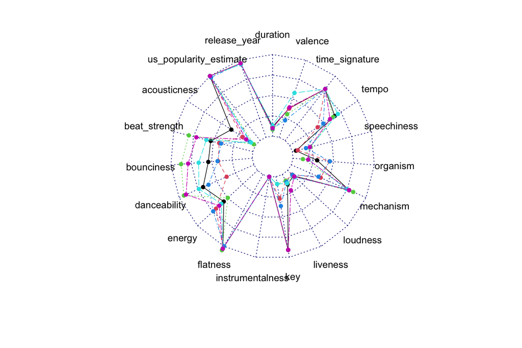

**Managing Shapes for Audience Perception**

We want to limit overinflated understanding of audio features based on the shape sizes that are perceived larger when adjacent categories differ considerably in value. In a chart like this with circular axes, the shape created grows in multiple dimensions related to variable on each of its sides as well as its placement on each axis/variable. This is different from e.g. a bar chart which is linear and will only increase in size in one direction along its axis. The risk with a radar chart is that we perceive greater emphasis on a data variable if it takes up more space of the polygon, i.e. it appears larger at that column data’s axis than perhaps is meaningful.

Another way to look at that is two axis with the same plotted point, may not look the same size or importance to the audience if one of them is next to points on their axes at a similar place, which would result in a ‘smaller’ shape there, compared to if one of them is next to points at very different places on their axes which requires a longer line or distance between points to close the shape and therefore could look ‘larger’ to the audience carrying greater perceptive emphasis with their understanding and conclusions from the graph.

Since the polygon shape can impact how we perceive sameness and different in magnitude on a radar graph, let’s reorder the columns to put same and similar scales in neighborhoods, start at the top with most emphasis–I’ll use popularity estimate, which look to all be above 90%. After some preliminary testing from viewing the default radar chart in our initial columns order, we are able to create and control a more visually accurate chart within this design, practicing our intention to limit misperceptions or our own misdirections in further analysis.

|  | us_popularity_estimate | release_year | duration | time_signature | tempo | key | loudness | acousticness | beat_strength | bounciness | danceability | liveness | mechanism | organism | energy | flatness | instrumentalness | speechiness | valence |
| --- | --- | --- | --- | --- | --- | --- | --- | --- | --- | --- | --- | --- | --- | --- | --- | --- | --- | --- | --- |
| Max | 100.00000 | 2021 | 2000.0000 | 5 | 220.000 | 11 | -60.000 | 1.00000000 | 1.0000000 | 1.0000000 | 1.0000000 | 1.00000000 | 1.0000000 | 1.0000000 | 1.0000000 | 1.0000000 | 1.0000000000000000 | 1.00000000 | 1.0000000 |
| Min | 0.00000 | 1950 | 0.0000 | 0 | 0.000 | 0 | 0.000 | 0.00000000 | 0.0000000 | 0.0000000 | 0.0000000 | 0.00000000 | 0.0000000 | 0.0000000 | 0.0000000 | 0.0000000 | 0.0000000000000000 | 0.00000000 | 0.0000000 |
| 1 | 99.99998 | 2018 | 231.2667 | 4 | 145.028 | 10 | -5.843 | 0.35411644 | 0.5321552 | 0.5404109 | 0.6797193 | 0.13577576 | 0.7743271 | 0.2969231 | 0.5630089 | 1.0294654 | 0.0000000265903513 | 0.04535428 | 0.3738621 |
| 2 | 99.99828 | 2018 | 203.4000 | 4 | 89.998 | 3 | -4.586 | 0.19181940 | 0.4254028 | 0.4194166 | 0.3646680 | 0.08617508 | 0.3938356 | 0.4495720 | 0.6918172 | 1.0268339 | 0.0000015122926698 | 0.06712231 | 0.3716313 |
| 3 | 99.99980 | 2018 | 161.0133 | 4 | 139.951 | 1 | -6.062 | 0.02539228 | 0.8089568 | 0.8750140 | 0.9363900 | 0.08703568 | 0.8287671 | 0.1224040 | 0.4954246 | 1.0538664 | 0.0000000000883577 | 0.22916549 | 0.2985733 |
| 4 | 97.82787 | 2018 | 189.4013 | 4 | 108.050 | 4 | -4.793 | 0.08292492 | 0.4013238 | 0.4267530 | 0.6073564 | 0.10513421 | 0.3633333 | 0.4539939 | 0.7395036 | 0.9975393 | 0.0000000106861657 | 0.17155994 | 0.2194498 |
| 5 | 99.99961 | 2017 | 264.5316 | 4 | 155.007 | 1 | -7.357 | 0.06516206 | 0.5873259 | 0.6591122 | 0.7359634 | 0.12350819 | 0.7379768 | 0.1909218 | 0.6036724 | 1.0310866 | 0.0000643250241410 | 0.22185422 | 0.5743871 |
| 6 | 99.99771 | 2018 | 197.3067 | 4 | 130.007 | 10 | -6.663 | 0.13678221 | 0.7135774 | 0.7886605 | 0.9079530 | 0.22036265 | 0.7725947 | 0.1876466 | 0.6381349 | 1.0338607 | 0.0000140744368764 | 0.22082488 | 0.3880620 |

[figure not shown]

| track_id_clean | plays | skip_1 | skip_2 | skip_3 | not_skipped | not_skipped_pct | duration | release_year | us_popularity_estimate | acousticness | beat_strength | bounciness | danceability | dyn_range_mean | energy | flatness | instrumentalness | key | liveness | loudness | mechanism | mode | organism | speechiness | tempo | time_signature | valence | acoustic_vector_0 | acoustic_vector_1 | … |
| --- | --- | --- | --- | --- | --- | --- | --- | --- | --- | --- | --- | --- | --- | --- | --- | --- | --- | --- | --- | --- | --- | --- | --- | --- | --- | --- | --- | --- | --- | --- |
| t_00750953-913d-4950-94a2-285b662c32f3 | 148 | 55 | 77 | 97 | 49 | 0.3310811 | 175.77464 | 2018 | 99.99898 | 0.012125714 | 0.8859758 | 0.9271444 | 0.9323004 | 19.970089 | 0.4805880 | 1.043179 | 0.0004971811431460 | 1 | 0.09703890 | -9.499 | 0.8663102 | minor | 0.09492104 | 0.16216677 | 142.078 | 4 | 0.1967254 | -0.73939264 | 0.2647474 | … |
| t_01d0b9bd-9b4c-4245-8e9e-1dd6b09be4b8 | 94 | 33 | 44 | 63 | 1 | 0.0106383 | 183.90668 | 2017 | 99.99822 | 0.193644717 | 0.6366841 | 0.6364808 | 0.7292920 | 8.971728 | 0.6247844 | 1.047307 | 0.0098643312230706 | 4 | 0.24785671 | -5.266 | 0.7881137 | major | 0.20297053 | 0.03152940 | 146.034 | 4 | 0.2606506 | -0.83243555 | 0.2644022 | … |
| t_01d7104d-d28c-4c56-9012-d22ef2b8bdc9 | 53 | 15 | 25 | 28 | 24 | 0.4528302 | 195.51900 | 2018 | 99.99979 | 0.002811538 | 0.4961974 | 0.4455178 | 0.6304825 | 6.607257 | 0.6942846 | 1.031873 | 0.0000000001266271 | 11 | 0.07186585 | -6.257 | 0.7737226 | minor | 0.16001461 | 0.02528419 | 97.005 | 4 | 0.2159331 | -0.45729017 | 0.5148367 | … |
| t_0214ad9b-a913-43f4-9111-0c04f5405449 | 58 | 30 | 40 | 46 | 11 | 0.1896552 | 204.60001 | 2017 | 99.99948 | 0.010180771 | 0.6939233 | 0.7632633 | 0.8328703 | 11.646129 | 0.4344342 | 1.075921 | 0.0219074171036482 | 2 | 0.16539416 | -8.795 | 0.7720930 | major | 0.16131528 | 0.43101573 | 150.062 | 4 | 0.2811260 | -0.72874880 | 0.2342471 | … |
| t_0303b567-f375-430c-9457-d41ccfbcdc59 | 56 | 20 | 28 | 30 | 26 | 0.4642857 | 99.65832 | 2018 | 99.99907 | 0.975538969 | 0.3693140 | 0.3744994 | 0.3559681 | 6.532290 | 0.1429399 | 1.057809 | 0.0000188813864952 | 9 | 0.11054670 | -15.148 | 0.2110092 | major | 0.88718176 | 0.03882124 | 75.522 | 4 | 0.3342692 | -0.01878756 | 0.1626284 | … |
| t_043b7b1a-444f-4d1c-9b46-c83895cb4d47 | 112 | 43 | 47 | 64 | 47 | 0.4196429 | 204.42667 | 2018 | 99.99976 | 0.413971514 | 0.3133208 | 0.3189231 | 0.4793661 | 6.058625 | 0.4681118 | 1.026327 | 0.0000000005543837 | 5 | 0.14812608 | -5.396 | 0.3122530 | major | 0.56761271 | 0.02740655 | 85.913 | 4 | 0.3496067 | -0.14557664 | 0.4947272 | … |

Now, I’ll repeat all that data prep and column order I did with the least skipped tracks to achieve a comparable result for a new radar chart. *Note this also would be a great scenario to create one or more functions for easier repeatability for consistent charting in the future.*

|  | us_popularity_estimate | release_year | duration | time_signature | tempo | key | loudness | acousticness | beat_strength | bounciness | danceability | liveness | mechanism | organism | energy | flatness | instrumentalness | speechiness | valence |
| --- | --- | --- | --- | --- | --- | --- | --- | --- | --- | --- | --- | --- | --- | --- | --- | --- | --- | --- | --- |
| Max | 100.00000 | 2021 | 2000.00000 | 5 | 220.000 | 11 | -60.000 | 1.000000000 | 1.0000000 | 1.0000000 | 1.0000000 | 1.00000000 | 1.0000000 | 1.00000000 | 1.0000000 | 1.000000 | 1.0000000000000000 | 1.00000000 | 1.0000000 |
| Min | 0.00000 | 1950 | 0.00000 | 0 | 0.000 | 0 | 0.000 | 0.000000000 | 0.0000000 | 0.0000000 | 0.0000000 | 0.00000000 | 0.0000000 | 0.00000000 | 0.0000000 | 0.000000 | 0.0000000000000000 | 0.00000000 | 0.0000000 |
| 1 | 99.99898 | 2018 | 175.77464 | 4 | 142.078 | 1 | -9.499 | 0.012125714 | 0.8859758 | 0.9271444 | 0.9323004 | 0.09703890 | 0.8663102 | 0.09492104 | 0.4805880 | 1.043179 | 0.0004971811431460 | 0.16216677 | 0.1967254 |
| 2 | 99.99822 | 2017 | 183.90668 | 4 | 146.034 | 4 | -5.266 | 0.193644717 | 0.6366841 | 0.6364808 | 0.7292920 | 0.24785671 | 0.7881137 | 0.20297053 | 0.6247844 | 1.047307 | 0.0098643312230706 | 0.03152940 | 0.2606506 |
| 3 | 99.99979 | 2018 | 195.51900 | 4 | 97.005 | 11 | -6.257 | 0.002811538 | 0.4961974 | 0.4455178 | 0.6304825 | 0.07186585 | 0.7737226 | 0.16001461 | 0.6942846 | 1.031873 | 0.0000000001266271 | 0.02528419 | 0.2159331 |
| 4 | 99.99948 | 2017 | 204.60001 | 4 | 150.062 | 2 | -8.795 | 0.010180771 | 0.6939233 | 0.7632633 | 0.8328703 | 0.16539416 | 0.7720930 | 0.16131528 | 0.4344342 | 1.075921 | 0.0219074171036482 | 0.43101573 | 0.2811260 |
| 5 | 99.99907 | 2018 | 99.65832 | 4 | 75.522 | 9 | -15.148 | 0.975538969 | 0.3693140 | 0.3744994 | 0.3559681 | 0.11054670 | 0.2110092 | 0.88718176 | 0.1429399 | 1.057809 | 0.0000188813864952 | 0.03882124 | 0.3342692 |
| 6 | 99.99976 | 2018 | 204.42667 | 4 | 85.913 | 5 | -5.396 | 0.413971514 | 0.3133208 | 0.3189231 | 0.4793661 | 0.14812608 | 0.3122530 | 0.56761271 | 0.4681118 | 1.026327 | 0.0000000005543837 | 0.02740655 | 0.3496067 |

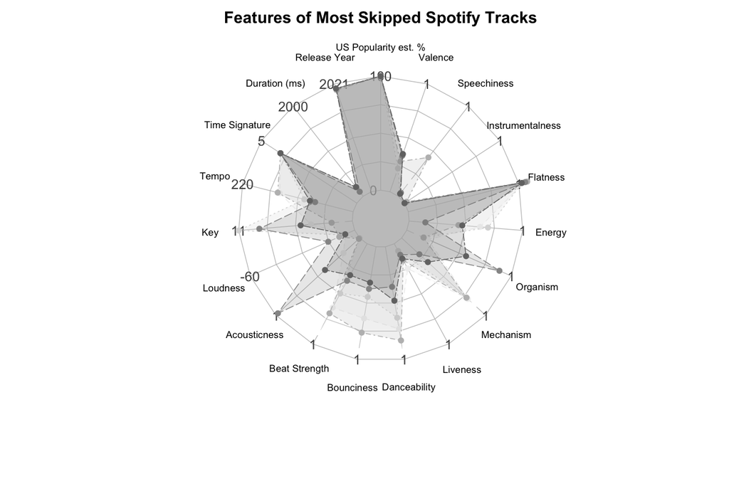

## Show Me the Side-by-Side Comparison!

Now we will plot the least and most skipped charts beside one another for comparison.

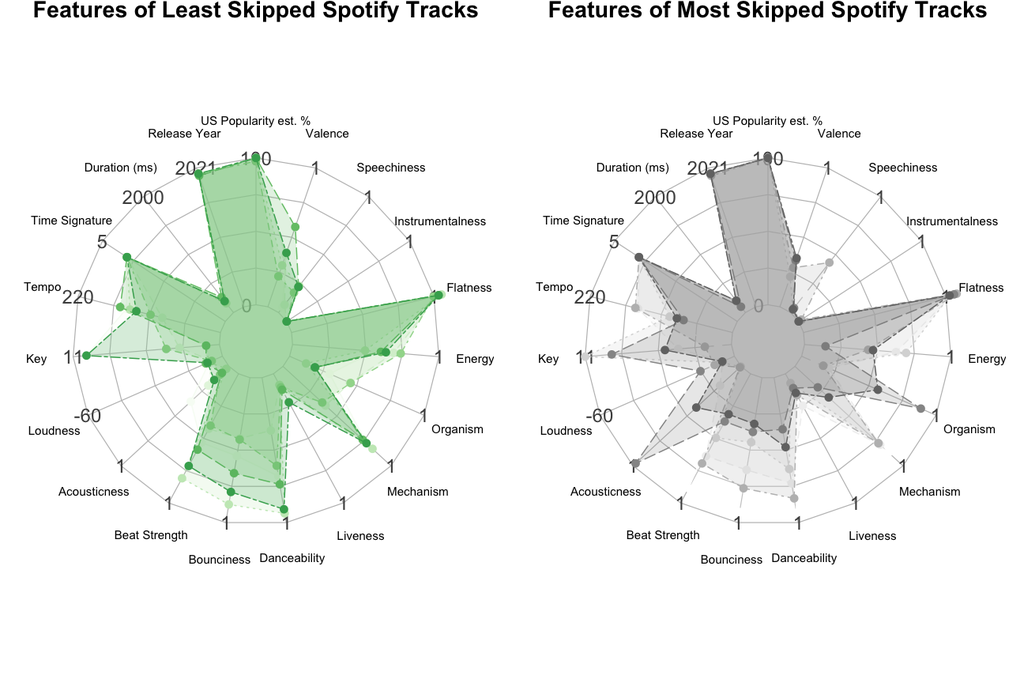

## Conclusions of Exploratory Data Analysis

Spotify users show trends of preferences toward playing songs through entirety with:

A categorical or neighborhood model could further assess these findings with a confidence level.

### List of Least Skipped Tracks

This could be modified and used as input for a Spotify Web Play to provide a listening experience to our musician, however I’ve updated the storyboard/roadmap below to indicate this would require using our own Spotify user data to compare track features, because after testing I confirmed this CSV training dataset contains anonymized track ID’s that do not meet the 22 character format and do not match actual tracks on Spotify.

### Planning Next Steps

A Story board / roadmap was made for this project called *Sell Out Music Roadmap* board was made in miro where you can also view it interactively https://miro.com/app/board/o9J_lJXf6B0=/

[output not shown]

## Link to the Sell Out Music Listener app

Jump over to the deployed app being made in Shiny https://data-design-dimension.shinyapps.io/Sell-Out-Music-Listener/ If you happen to catch it reading “Disconnected from server”, let me know on Slack or email me at kmhurchla@gmail.com and I’ll wake it up for you! All this building and debugging, it gets sleepy sometimes!

### Data & Cited Sources

Sample data contains over 300 unique tracks each played 50 times or more as analyzed in this notebook, of the *Training_Set_And_Track_Features_Mini (17.2 MB)* from AI Crowd Spotify Sequential Skip Prediction Challenge By Spotify, which sponsored the AI Crowd challenge (https://www.spotify.com/).

**Data source(s):** https://www.aicrowd.com/challenges/spotify-sequential-skip-prediction-challenge/dataset_files Training_Set_And_Track_Features_Mini 17.2 MB Minimally sized version of training set and track features for familiarizing yourself with dataset on aicrowd Spotify Sequential Skip Prediction Challenge

**Image source(s):** Spotify Icon: [Spotify Icon](https://iconscout.com/icons/spotify) by [Jojo Mendoza](https://iconscout.com/contributors/Hopstarter)

Next Icon: [Next Icon](https://iconscout.com/icons/next) by [Saepul Nahwan](https://iconscout.com/contributors/saepul-nahwan) on [Iconscout](https://iconscout.com)

Fast Icon: [Fast Icon](https://iconscout.com/icons/fast) by [Taufik Ramadhan](https://iconscout.com/contributors/taufik) on [Iconscout](https://iconscout.com)

Headphone Icon: [Headphone Icon](https://iconscout.com/icons/headphone) by [Fatkhul Karim](https://iconscout.com/contributors/fatkhulkarim)

**Cited:** All last accessed with published notebook date except where otherwise noted.

Produced with instructive direction and initial coding starts from Justin Elszasz "justin.elszasz@baltimorecity.gov as part of MICA Data Analytics & Visualization program course Visual Storytelling.

Radar Chart guidelines/bestpractices and FSMB package requirements: https://www.r-graph-gallery.com/spider-or-radar-chart.html

The Radar Chart and its Caveats, A collection of common dataviz caveats by Data-to-Viz.com: https://www.data-to-viz.com/caveat/spider.html

Spotify Developer documentation: https://developer.spotify.com/documentation/web-api/reference/#endpoint-search See especially terms under section “AudioFeaturesObject”.

Reserach info on Time Signature: https://www.libertyparkmusic.com/musical-time-signatures/#

and Tempo: https://www.masterclass.com/articles/music-101-what-is-tempo-how-is-tempo-used-in-music#what-is-casual-musical-language